# Modelo Lineal Multivariado - Clase 3

Cecilia Oliva

13/06/2023

# Modelo lineal mulivariado

## Modelo aditivo

### Ejemplo de pesos de recién nacidos

Analizamos los siguientes datos que corresponden a mediciones de 100 niños nacidos con bajo peso (es decir, con menos de 1500 g.) en Boston, Massachusetts.

Las variables que usaremos son:

headcirc: es el perímetro cefálico (medido en cm.) de un bebé recién nacido con bajo peso,

gestage: es la edad gestacional o duración de la gestación del i-ésimo bebé de bajo peso,

birthwt: es el peso al nacer del i-ésimo niño, en gramos.

```r
file<-"low birth weight infants.txt"

data <- read.table(file = file, header = TRUE)
head(data)
```

|  | headcirc | length | gestage | birthwt | momage | toxemia |
| --- | --- | --- | --- | --- | --- | --- |
| 1 | 27 | 41 | 29 | 1360 | 37 | 0 |
| 2 | 29 | 40 | 31 | 1490 | 34 | 0 |
| 3 | 30 | 38 | 33 | 1490 | 32 | 0 |
| 4 | 28 | 38 | 31 | 1180 | 37 | 0 |
| 5 | 29 | 38 | 30 | 1200 | 29 | 1 |
| 6 | 23 | 32 | 25 | 680 | 19 | 0 |

```r
names(data)
```

```
## [1] "headcirc" "length"   "gestage"  "birthwt"  "momage"   "toxemia"
```

```r
dim(data)
```

```
## [1] 100   6
```

```r
summary(data$headcirc)
```

```
##    Min. 1st Qu.  Median    Mean 3rd Qu.    Max.
##   21.00   25.00   27.00   26.45   28.00   35.00
```

Ajustamos el perímetro cefálico, mediante un modelo lineal, a las covariables de edad gestacional y de peso al nacer.

```r
model_lin_adi<-lm(headcirc ~ gestage+birthwt, data = data)
summary(model_lin_adi)
```

```
##
## Call:
## lm(formula = headcirc ~ gestage + birthwt, data = data)
##
## Residuals:
##     Min      1Q  Median      3Q     Max
## -2.0350 -0.7271 -0.0765  0.3472  8.5402
##
## Coefficients:
##              Estimate Std. Error t value Pr(>|t|)
## (Intercept) 8.3080154  1.5789429   5.262 8.54e-07 ***
## gestage     0.4487328  0.0672460   6.673 1.56e-09 ***
## birthwt     0.0047123  0.0006312   7.466 3.60e-11 ***
## ---
## Signif. codes:  0 '***' 0.001 '**' 0.01 '*' 0.05 '.' 0.1 ' ' 1
##
## Residual standard error: 1.274 on 97 degrees of freedom
## Multiple R-squared:  0.752,  Adjusted R-squared:  0.7469
## F-statistic: 147.1 on 2 and 97 DF,  p-value: < 2.2e-16
```

Generamos nuevos valores de las variables y obtenemos la predicción del perímetro cefálico para esos nuevos datos.

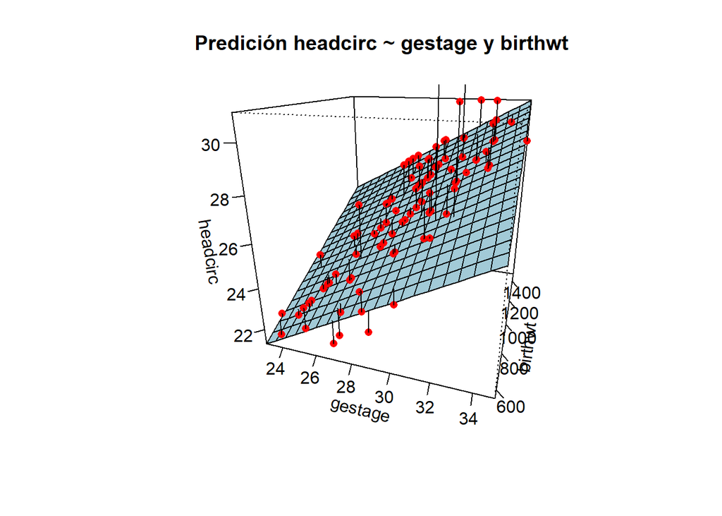

```r
rango_gestage <- range(data$gestage)
nuevos_valores_gestage <- seq(from = rango_gestage[1], to = rango_gestage[2], length.out = 20)
rango_birthwt <- range(data$birthwt)
nuevos_valores_birthwt <- seq(from = rango_birthwt[1], to = rango_birthwt[2], length.out = 20)
predicciones <- outer(X = nuevos_valores_gestage, Y = nuevos_valores_birthwt, FUN = function(gestage, birthwt) {predict(object = model_lin_adi, newdata = data.frame(gestage, birthwt)) })
superficie <- persp(x = nuevos_valores_gestage, y = nuevos_valores_birthwt, z = predicciones, theta = 18, phi = 20, col = "lightblue", shade = 0.1, xlab = "gestage", ylab = "birthwt", zlab = "headcirc", ticktype = "detailed", main = "Predición headcirc ~ gestage y birthwt")
observaciones <- trans3d(data$gestage, data$birthwt, data$headcirc, superficie)
error <- trans3d(data$gestage, data$birthwt, fitted(model_lin_adi), superficie)
points(observaciones, col = "red", pch = 16)
segments(observaciones$x, observaciones$y, error$x, error$y)
```

## Modelos lineales robustos

### Mismo ejemplo anterior de datos de niños de bajo peso al nacer

Probamos un modelo robusto sobre el modelo lineal completo, usando todas las variables continuas, y otro usando sólo las más significativas.

```r
library(robustbase)
ajusterob <- lmrob(headcirc ~ ., data = data)
summary(ajusterob)
```

```
##
## Call:
## lmrob(formula = headcirc ~ ., data = data)
##  \--> method = "MM"
## Residuals:
##     Min      1Q  Median      3Q     Max
## -1.4347 -0.4967  0.0409  0.4492  8.8964
##
## Coefficients:
##               Estimate Std. Error t value Pr(>|t|)
## (Intercept)  9.6768394  1.2487092   7.749 1.07e-11 ***
## length       0.0016911  0.0342496   0.049    0.961
## gestage      0.3823177  0.0497471   7.685 1.45e-11 ***
## birthwt      0.0051928  0.0004407  11.783  < 2e-16 ***
## momage      -0.0069328  0.0125415  -0.553    0.582
## toxemia     -0.1942121  0.3317222  -0.585    0.560
## ---
## Signif. codes:  0 '***' 0.001 '**' 0.01 '*' 0.05 '.' 0.1 ' ' 1
##
## Robust residual standard error: 0.7464
## Multiple R-squared:  0.8933, Adjusted R-squared:  0.8876
## Convergence in 14 IRWLS iterations
##
## Robustness weights:
##  2 observations c(31,33) are outliers with |weight| = 0 ( < 0.001);
##  11 weights are ~= 1. The remaining 87 ones are summarized as
##    Min. 1st Qu.  Median    Mean 3rd Qu.    Max.
##  0.1152  0.8629  0.9506  0.8927  0.9843  0.9984
## Algorithmic parameters:
##        tuning.chi                bb        tuning.psi        refine.tol
##         1.548e+00         5.000e-01         4.685e+00         1.000e-07
##           rel.tol         scale.tol         solve.tol       eps.outlier
##         1.000e-07         1.000e-10         1.000e-07         1.000e-03
##             eps.x warn.limit.reject warn.limit.meanrw
##         2.710e-09         5.000e-01         5.000e-01
##      nResample         max.it       best.r.s       k.fast.s          k.max
##            500             50              2              1            200
##    maxit.scale      trace.lev            mts     compute.rd fast.s.large.n
##            200              0           1000              0           2000
##                   psi           subsampling                   cov
##            "bisquare"         "nonsingular"         ".vcov.avar1"
## compute.outlier.stats
##                  "SM"
## seed : int(0)
```

```r
ajusterob2 <- lmrob(headcirc ~ gestage+birthwt, data = data)
summary(ajusterob2)
```

```
##
## Call:
## lmrob(formula = headcirc ~ gestage + birthwt, data = data)
##  \--> method = "MM"
## Residuals:
##      Min       1Q   Median       3Q      Max
## -1.54442 -0.50286  0.04166  0.47961  9.03552
##
## Coefficients:
##              Estimate Std. Error t value Pr(>|t|)
## (Intercept) 1.003e+01  1.062e+00   9.449 2.07e-15 ***
## gestage     3.592e-01  4.445e-02   8.082 1.80e-12 ***
## birthwt     5.327e-03  3.532e-04  15.083  < 2e-16 ***
## ---
## Signif. codes:  0 '***' 0.001 '**' 0.01 '*' 0.05 '.' 0.1 ' ' 1
##
## Robust residual standard error: 0.7884
## Multiple R-squared:  0.8874, Adjusted R-squared:  0.8851
## Convergence in 12 IRWLS iterations
##
## Robustness weights:
##  2 observations c(31,33) are outliers with |weight| = 0 ( < 0.001);
##  11 weights are ~= 1. The remaining 87 ones are summarized as
##    Min. 1st Qu.  Median    Mean 3rd Qu.    Max.
##  0.1910  0.8747  0.9537  0.9023  0.9836  0.9989
## Algorithmic parameters:
##        tuning.chi                bb        tuning.psi        refine.tol
##         1.548e+00         5.000e-01         4.685e+00         1.000e-07
##           rel.tol         scale.tol         solve.tol       eps.outlier
##         1.000e-07         1.000e-10         1.000e-07         1.000e-03
##             eps.x warn.limit.reject warn.limit.meanrw
##         2.710e-09         5.000e-01         5.000e-01
##      nResample         max.it       best.r.s       k.fast.s          k.max
##            500             50              2              1            200
##    maxit.scale      trace.lev            mts     compute.rd fast.s.large.n
##            200              0           1000              0           2000
##                   psi           subsampling                   cov
##            "bisquare"         "nonsingular"         ".vcov.avar1"
## compute.outlier.stats
##                  "SM"
## seed : int(0)
```

Probamos otros modelos robustos usando las funciones de Huber y bicuadrada.

```r
library(MASS)
rob_mod_lin_adi_huber<-rlm(headcirc ~ gestage+birthwt, data = data,psi = psi.huber)#psi.huber por default
summary(rob_mod_lin_adi_huber)
```

```
##
## Call: rlm(formula = headcirc ~ gestage + birthwt, data = data, psi = psi.huber)
## Residuals:
##      Min       1Q   Median       3Q      Max
## -1.64593 -0.54668  0.03503  0.45208  8.96052
##
## Coefficients:
##             Value   Std. Error t value
## (Intercept)  9.6925  1.0699     9.0594
## gestage      0.3743  0.0456     8.2153
## birthwt      0.0053  0.0004    12.3216
##
## Residual standard error: 0.7338 on 97 degrees of freedom
```

```r
rob_mod_lin_adi_biscuad<-rlm(headcirc ~ gestage+birthwt, data = data,psi = psi.bisquare)
summary(rob_mod_lin_adi_biscuad)
```

```
##
## Call: rlm(formula = headcirc ~ gestage + birthwt, data = data, psi = psi.bisquare)
## Residuals:
##      Min       1Q   Median       3Q      Max
## -1.53091 -0.49630  0.04738  0.48792  9.04771
##
## Coefficients:
##             Value   Std. Error t value
## (Intercept) 10.0595  0.9957    10.1029
## gestage      0.3578  0.0424     8.4374
## birthwt      0.0053  0.0004    13.4026
##
## Residual standard error: 0.7276 on 97 degrees of freedom
```

Observar que disminuye el error estándar residual en el último modelo.

## Análisis de multicolinealidad

### Ejemplo de índice de masa corporal infantil

```r
library(readxl)
IMCinfantil<-read_excel("C:/Users/cecim/Documents/Ce/AID/DataSets/IMCinfantil.xlsx")
dim(IMCinfantil)#150 9
```

```
## [1] 150   9
```

```r
head(IMCinfantil)
```

| PACIENTE | EDAD | SEXO | PESO | TALLA | IMC | PIMC | CC | CatPeso |
| --- | --- | --- | --- | --- | --- | --- | --- | --- |
| 1 | 7 | M | 24.4 | 1.2 | 16.94444 | 7.97 | 54 | N |
| 2 | 7 | M | 23.6 | 1.2 | 16.38889 | 72.72 | 52 | N |
| 3 | 8 | M | 47.0 | 1.4 | 23.97959 | 97.08 | 76 | OB |
| 4 | 7 | F | 24.0 | 1.2 | 16.66667 | 83.88 | 63 | N |
| 5 | 7 | M | 23.9 | 1.2 | 16.59722 | 45.85 | 56 | N |
| 6 | 10 | M | 41.0 | 1.4 | 20.91837 | 87.33 | 78 | SO |

```r
attach(IMCinfantil) # carga la base en la memoria activa
base.ninios=data.frame(EDAD,PESO,TALLA,IMC,CC) # arma una sub-base con las variables numéricas de IMCinfantil
```

Aplicamos un modelo lineal múltiple para estimar IMC.

```r
ajusteL <- lm(IMC ~ ., data = base.ninios)
summary(ajusteL)
```

```
##
## Call:
## lm(formula = IMC ~ ., data = base.ninios)
##
## Residuals:
##     Min      1Q  Median      3Q     Max
## -3.8103 -0.3783  0.1029  0.4262  1.4033
##
## Coefficients:
##              Estimate Std. Error t value Pr(>|t|)
## (Intercept)  31.33035    1.33544  23.461  < 2e-16 ***
## EDAD         -0.05889    0.06353  -0.927 0.355477
## PESO          0.45053    0.01829  24.627  < 2e-16 ***
## TALLA       -22.93879    1.21921 -18.814  < 2e-16 ***
## CC            0.04663    0.01370   3.405 0.000855 ***
## ---
## Signif. codes:  0 '***' 0.001 '**' 0.01 '*' 0.05 '.' 0.1 ' ' 1
##
## Residual standard error: 0.6698 on 145 degrees of freedom
## Multiple R-squared:  0.9619, Adjusted R-squared:  0.9609
## F-statistic: 915.5 on 4 and 145 DF,  p-value: < 2.2e-16
```

Calculamos el VIF (valor de inflación de la varianza) de cada variable.

```r
library(car)
car::vif(ajusteL)
```

```
##      EDAD      PESO     TALLA        CC
##  3.553780 13.848533  7.557218  7.178616
```

**Observación**: notar que la única variable no significativa es la que no tiene alto VIF (alto VIF es mayor a 5).

Probamos eliminar la variable que tiene VIF superior (PESO), recordar además que PESO y CC tienen alta correlación=0.92, conviene más aún sacar entonces PESO.

```r
ajusteLin <- lm(IMC ~ EDAD+TALLA+CC, data = base.ninios)
summary(ajusteLin)
```

```
##
## Call:
## lm(formula = IMC ~ EDAD + TALLA + CC, data = base.ninios)
##
## Residuals:
##     Min      1Q  Median      3Q     Max
## -5.5918 -0.8006  0.1030  0.9390  3.5799
##
## Coefficients:
##             Estimate Std. Error t value Pr(>|t|)
## (Intercept)   3.6362     1.6342   2.225   0.0276 *
## EDAD         -0.2338     0.1432  -1.633   0.1047
## TALLA        -3.4775     2.1065  -1.651   0.1009
## CC            0.3297     0.0169  19.513   <2e-16 ***
## ---
## Signif. codes:  0 '***' 0.001 '**' 0.01 '*' 0.05 '.' 0.1 ' ' 1
##
## Residual standard error: 1.52 on 146 degrees of freedom
## Multiple R-squared:  0.8026, Adjusted R-squared:  0.7985
## F-statistic: 197.9 on 3 and 146 DF,  p-value: < 2.2e-16
```

Calculamos nuevamente el VIF de cada variable.

```r
car::vif(ajusteLin)
```

```
##     EDAD    TALLA       CC
## 3.509351 4.382513 2.122734
```

Ya no se observan valores muy altos de VIF, por lo que no parece haber multicolinealidad.

## Regresión polinómica

Retomamos el ejemplo de los pesos de bebés al nacer. Ajustamos el perímetro cefálico, mediante un modelo lineal, a las covariables de edad gestacional y de peso al nacer.

```r
model_lin_adi<-lm(headcirc ~ gestage+birthwt, data = data)
summary(model_lin_adi)
```

```
##
## Call:
## lm(formula = headcirc ~ gestage + birthwt, data = data)
##
## Residuals:
##     Min      1Q  Median      3Q     Max
## -2.0350 -0.7271 -0.0765  0.3472  8.5402
##
## Coefficients:
##              Estimate Std. Error t value Pr(>|t|)
## (Intercept) 8.3080154  1.5789429   5.262 8.54e-07 ***
## gestage     0.4487328  0.0672460   6.673 1.56e-09 ***
## birthwt     0.0047123  0.0006312   7.466 3.60e-11 ***
## ---
## Signif. codes:  0 '***' 0.001 '**' 0.01 '*' 0.05 '.' 0.1 ' ' 1
##
## Residual standard error: 1.274 on 97 degrees of freedom
## Multiple R-squared:  0.752,  Adjusted R-squared:  0.7469
## F-statistic: 147.1 on 2 and 97 DF,  p-value: < 2.2e-16
```

Ajustamos ahora a través de un polinomio de orden 2 sobre la variable gestage.

```r
model_poly2 <- lm(formula = headcirc ~ gestage + I(gestage^2), data = data)
summary(model_poly2)
```

```
##
## Call:
## lm(formula = headcirc ~ gestage + I(gestage^2), data = data)
##
## Residuals:
##     Min      1Q  Median      3Q     Max
## -3.7108 -0.8075 -0.1178  0.8709  6.8596
##
## Coefficients:
##               Estimate Std. Error t value Pr(>|t|)
## (Intercept)  -18.86378   16.03740  -1.176    0.242
## gestage        2.37297    1.11605   2.126    0.036 *
## I(gestage^2)  -0.02764    0.01933  -1.430    0.156
## ---
## Signif. codes:  0 '***' 0.001 '**' 0.01 '*' 0.05 '.' 0.1 ' ' 1
##
## Residual standard error: 1.582 on 97 degrees of freedom
## Multiple R-squared:  0.6175, Adjusted R-squared:  0.6097
## F-statistic: 78.31 on 2 and 97 DF,  p-value: < 2.2e-16
```

```r
model_poly2bis <- lm(formula = headcirc ~ poly(gestage, 2), data = data)
summary(model_poly2bis)
```

```
##
## Call:
## lm(formula = headcirc ~ poly(gestage, 2), data = data)
##
## Residuals:
##     Min      1Q  Median      3Q     Max
## -3.7108 -0.8075 -0.1178  0.8709  6.8596
##
## Coefficients:
##                   Estimate Std. Error t value Pr(>|t|)
## (Intercept)        26.4500     0.1582  167.19   <2e-16 ***
## poly(gestage, 2)1  19.6689     1.5820   12.43   <2e-16 ***
## poly(gestage, 2)2  -2.2615     1.5820   -1.43    0.156
## ---
## Signif. codes:  0 '***' 0.001 '**' 0.01 '*' 0.05 '.' 0.1 ' ' 1
##
## Residual standard error: 1.582 on 97 degrees of freedom
## Multiple R-squared:  0.6175, Adjusted R-squared:  0.6097
## F-statistic: 78.31 on 2 and 97 DF,  p-value: < 2.2e-16
```

```r
model_poly2bis0 <- lm(formula = headcirc ~ poly(gestage, 2,raw=TRUE), data = data)
summary(model_poly2bis0)#da lo mismo que el poly2
```

```
##
## Call:
## lm(formula = headcirc ~ poly(gestage, 2, raw = TRUE), data = data)
##
## Residuals:
##     Min      1Q  Median      3Q     Max
## -3.7108 -0.8075 -0.1178  0.8709  6.8596
##
## Coefficients:
##                                Estimate Std. Error t value Pr(>|t|)
## (Intercept)                   -18.86378   16.03740  -1.176    0.242
## poly(gestage, 2, raw = TRUE)1   2.37297    1.11605   2.126    0.036 *
## poly(gestage, 2, raw = TRUE)2  -0.02764    0.01933  -1.430    0.156
## ---
## Signif. codes:  0 '***' 0.001 '**' 0.01 '*' 0.05 '.' 0.1 ' ' 1
##
## Residual standard error: 1.582 on 97 degrees of freedom
## Multiple R-squared:  0.6175, Adjusted R-squared:  0.6097
## F-statistic: 78.31 on 2 and 97 DF,  p-value: < 2.2e-16
```

**Observar** que el tercer modelo es igual al primero.

Nuevamente aplicamos una regresión polinomial de orden 2, agregando la variable birthwt.

```r
model_poly2_comp <- lm(formula = headcirc ~ gestage + I(gestage^2)+birthwt + I(birthwt^2), data = data)
summary(model_poly2_comp)
```

```
##
## Call:
## lm(formula = headcirc ~ gestage + I(gestage^2) + birthwt + I(birthwt^2),
##     data = data)
##
## Residuals:
##     Min      1Q  Median      3Q     Max
## -1.8169 -0.6810 -0.1153  0.4054  8.3509
##
## Coefficients:
##                Estimate Std. Error t value Pr(>|t|)
## (Intercept)  -2.383e+00  1.331e+01  -0.179   0.8583
## gestage       1.029e+00  9.701e-01   1.061   0.2914
## I(gestage^2) -9.804e-03  1.678e-02  -0.584   0.5605
## birthwt       9.289e-03  4.295e-03   2.163   0.0331 *
## I(birthwt^2) -2.238e-06  2.048e-06  -1.093   0.2773
## ---
## Signif. codes:  0 '***' 0.001 '**' 0.01 '*' 0.05 '.' 0.1 ' ' 1
##
## Residual standard error: 1.272 on 95 degrees of freedom
## Multiple R-squared:  0.7579, Adjusted R-squared:  0.7477
## F-statistic: 74.34 on 4 and 95 DF,  p-value: < 2.2e-16
```

```r
model_poly2_comp_bis <- lm(formula = headcirc ~ poly(gestage,2)+poly(birthwt,2), data = data)
summary(model_poly2_comp_bis)
```

```
##
## Call:
## lm(formula = headcirc ~ poly(gestage, 2) + poly(birthwt, 2),
##     data = data)
##
## Residuals:
##     Min      1Q  Median      3Q     Max
## -1.8169 -0.6810 -0.1153  0.4054  8.3509
##
## Coefficients:
##                   Estimate Std. Error t value Pr(>|t|)
## (Intercept)        26.4500     0.1272 207.959  < 2e-16 ***
## poly(gestage, 2)1  11.7034     1.7147   6.825 8.19e-10 ***
## poly(gestage, 2)2  -0.8023     1.3734  -0.584    0.560
## poly(birthwt, 2)1  12.3442     1.7057   7.237 1.18e-10 ***
## poly(birthwt, 2)2  -1.5128     1.3845  -1.093    0.277
## ---
## Signif. codes:  0 '***' 0.001 '**' 0.01 '*' 0.05 '.' 0.1 ' ' 1
##
## Residual standard error: 1.272 on 95 degrees of freedom
## Multiple R-squared:  0.7579, Adjusted R-squared:  0.7477
## F-statistic: 74.34 on 4 and 95 DF,  p-value: < 2.2e-16
```

```r
model_poly2_comp_bis0 <- lm(formula = headcirc ~ poly(gestage,2,raw=TRUE)+poly(birthwt,2,raw=TRUE), data = data)
summary(model_poly2_comp_bis0)#da lo mismo que el poly2_com
```

```
##
## Call:
## lm(formula = headcirc ~ poly(gestage, 2, raw = TRUE) + poly(birthwt,
##     2, raw = TRUE), data = data)
##
## Residuals:
##     Min      1Q  Median      3Q     Max
## -1.8169 -0.6810 -0.1153  0.4054  8.3509
##
## Coefficients:
##                                 Estimate Std. Error t value Pr(>|t|)
## (Intercept)                   -2.383e+00  1.331e+01  -0.179   0.8583
## poly(gestage, 2, raw = TRUE)1  1.029e+00  9.701e-01   1.061   0.2914
## poly(gestage, 2, raw = TRUE)2 -9.804e-03  1.678e-02  -0.584   0.5605
## poly(birthwt, 2, raw = TRUE)1  9.289e-03  4.295e-03   2.163   0.0331 *
## poly(birthwt, 2, raw = TRUE)2 -2.238e-06  2.048e-06  -1.093   0.2773
## ---
## Signif. codes:  0 '***' 0.001 '**' 0.01 '*' 0.05 '.' 0.1 ' ' 1
##
## Residual standard error: 1.272 on 95 degrees of freedom
## Multiple R-squared:  0.7579, Adjusted R-squared:  0.7477
## F-statistic: 74.34 on 4 and 95 DF,  p-value: < 2.2e-16
```

**Observar** que el tercer modelo es igual al primero.

El siguiente modelo agrega la interacción entre gestage y birthwt.

```r
model_poly2_comp_bis2 <- lm(formula = headcirc ~ poly(gestage,2)+poly(birthwt,2) + I(gestage*birthwt), data = data)
summary(model_poly2_comp_bis2)
```

```
##
## Call:
## lm(formula = headcirc ~ poly(gestage, 2) + poly(birthwt, 2) +
##     I(gestage * birthwt), data = data)
##
## Residuals:
##     Min      1Q  Median      3Q     Max
## -1.7567 -0.7158 -0.1243  0.3537  8.1509
##
## Coefficients:
##                        Estimate Std. Error t value Pr(>|t|)
## (Intercept)          41.9897740 14.8009271   2.837  0.00558 **
## poly(gestage, 2)1    24.3701375 12.1851929   2.000  0.04839 *
## poly(gestage, 2)2     1.5691901  2.6430363   0.594  0.55413
## poly(birthwt, 2)1    50.0062098 35.9105615   1.393  0.16705
## poly(birthwt, 2)2    -0.2569849  1.8290235  -0.141  0.88856
## I(gestage * birthwt) -0.0004827  0.0004597  -1.050  0.29643
## ---
## Signif. codes:  0 '***' 0.001 '**' 0.01 '*' 0.05 '.' 0.1 ' ' 1
##
## Residual standard error: 1.271 on 94 degrees of freedom
## Multiple R-squared:  0.7607, Adjusted R-squared:  0.748
## F-statistic: 59.76 on 5 and 94 DF,  p-value: < 2.2e-16
```

**Importante**: notar que al dejar raw=FALSE (por defecto) R considera polinomios ortogonales, y eso hace que las distintas potencias de la variable no queden correlacionadas, lo que resulta más claro para entender cuánto aporta considerar una potencia más grande cada vez.

## Selección de variables

```r
#NO puede haber datos faltantes para aplicar lo que sigue:
require(leaps)
mejores_modelos <- regsubsets(headcirc ~ ., data = data, nvmax = 5)
```

El argumento nvmax determina el tamaño máximo de los modelos a inspeccionar. Si se quiere realizar best subset selection evaluando todos los posibles modelos, nvmax tiene que ser igual al número de variables disponibles.

```r
summary(mejores_modelos)
```

```
## Subset selection object
## Call: regsubsets.formula(headcirc ~ ., data = data, nvmax = 5)
## 5 Variables  (and intercept)
##         Forced in Forced out
## length      FALSE      FALSE
## gestage     FALSE      FALSE
## birthwt     FALSE      FALSE
## momage      FALSE      FALSE
## toxemia     FALSE      FALSE
## 1 subsets of each size up to 5
## Selection Algorithm: exhaustive
##          length gestage birthwt momage toxemia
## 1  ( 1 ) " "    " "     "*"     " "    " "
## 2  ( 1 ) " "    "*"     "*"     " "    " "
## 3  ( 1 ) " "    "*"     "*"     " "    "*"
## 4  ( 1 ) " "    "*"     "*"     "*"    "*"
## 5  ( 1 ) "*"    "*"     "*"     "*"    "*"
```

```r
names(summary(mejores_modelos))
```

```
## [1] "which"  "rsq"    "rss"    "adjr2"  "cp"     "bic"    "outmat" "obj"
```

```r
summary(mejores_modelos)$adjr2
```

```
## [1] 0.6344485 0.7468784 0.7492778 0.7514319 0.7488303
```

```r
# se identifica qué modelo tiene el valor máximo de R ajustado
which.max(summary(mejores_modelos)$adjr2)
```

```
## [1] 4
```

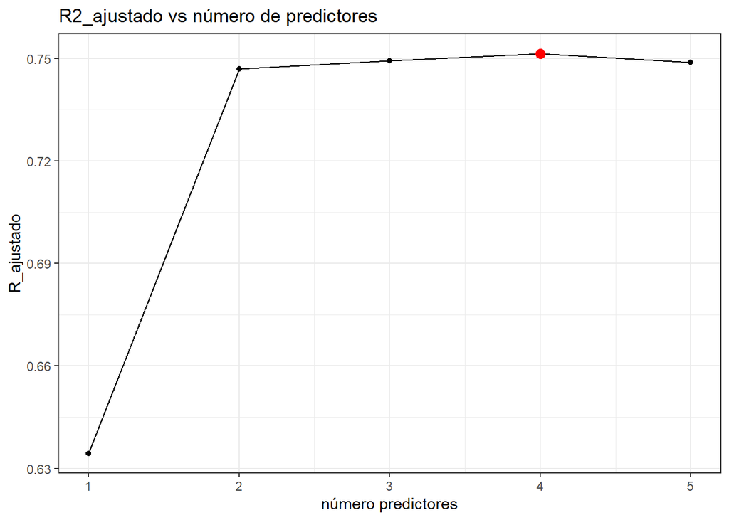

```r
library(ggplot2)
p <- ggplot(data = data.frame(n_predictores = 1:5, R_ajustado = summary(mejores_modelos)$adjr2), aes(x = n_predictores, y = R_ajustado)) +
  geom_line() +
  geom_point()
# Se identifica en rojo el máximo
p <- p + geom_point(aes(x=n_predictores[which.max(summary(mejores_modelos)$adjr2)], y=R_ajustado[which.max(summary(mejores_modelos)$adjr2)]), colour = "red", size = 3)
p <- p + scale_x_continuous(breaks = c(0:5)) + theme_bw() +
  labs(title = "R2_ajustado vs número de predictores", x = "número predictores")
p
```

```r
coef(object = mejores_modelos, id = 4)
```

```
##  (Intercept)      gestage      birthwt       momage      toxemia
##  7.351659066  0.528813058  0.004327508 -0.029787657 -0.515898351
```

### Backward

```r
require(leaps)
mejores_modelos_backward <- regsubsets(headcirc ~ ., data = data, nvmax = 5, method = "backward")
# se identifica el valor máximo de R ajustado
which.max(summary(mejores_modelos_backward)$adjr2)
```

```
## [1] 4
```

```r
coef(object = mejores_modelos_backward, 4)
```

```
##  (Intercept)      gestage      birthwt       momage      toxemia
##  7.351659066  0.528813058  0.004327508 -0.029787657 -0.515898351
```

### Forward

```r
mejores_modelos_forward <- regsubsets(headcirc ~ ., data = data, nvmax = 5, method = "forward")
# se identifica el valor máximo de R ajustado
which.max(summary(mejores_modelos_forward)$adjr2)
```

```
## [1] 4
```

```r
coef(object = mejores_modelos_forward, 4)
```

```
##  (Intercept)      gestage      birthwt       momage      toxemia
##  7.351659066  0.528813058  0.004327508 -0.029787657 -0.515898351
```

### Todas las combinaciones de modelos

```r
library(olsrr)
lm.fit1 <- lm(headcirc ~ ., data = data)
k <- ols_step_all_possible(lm.fit1)

# AIC: Akaike Information Criteria
# SBIC: Sawa's Bayesian Information Criteria
# SBC: Schwarz Bayesian Criteria
# MSEP: Estimated error of prediction, assuming multivariate normality
# FPE: Final Prediction Error
# HSP: Hocking's Sp
# APC: Amemiya Prediction Criteria

k # OJO: en RStudio se ven menos columnas en la salida
```

|  | mindex | n | predictors | rsquare | adjr | predrsq | cp | aic | sbic | sbc | msep | fpe | apc | hsp |
| --- | --- | --- | --- | --- | --- | --- | --- | --- | --- | --- | --- | --- | --- | --- |
| 3 | 1 | 1 | birthwt | 0.63814092 | 0.634448482 | 0.62465399 | 46.628891 | 372.9438 | 87.78188 | 380.7593 | 234.3786 | 2.390652 | 0.3766288 | 0.02416264 |
| 2 | 2 | 1 | gestage | 0.60947990 | 0.605495000 | 0.59544114 | 57.925802 | 380.5662 | 95.13170 | 388.3817 | 252.9425 | 2.580003 | 0.4064597 | 0.02607644 |
| 1 | 3 | 1 | length | 0.50798860 | 0.502968072 | 0.46373272 | 97.929198 | 403.6685 | 117.47419 | 411.4840 | 318.6791 | 3.250514 | 0.5120935 | 0.03285338 |
| 4 | 4 | 1 | momage | 0.01745530 | 0.007429332 | -0.02911380 | 291.275792 | 472.8329 | 184.97752 | 480.6484 | 636.4008 | 6.491262 | 1.0226486 | 0.06560806 |
| 5 | 5 | 1 | toxemia | 0.01743530 | 0.007409132 | -0.02360459 | 291.283673 | 472.8349 | 184.97952 | 480.6504 | 636.4138 | 6.491394 | 1.0226694 | 0.06560940 |
| 10 | 6 | 2 | gestage birthwt | 0.75199197 | 0.746878406 | 0.73222000 | 3.753827 | 337.1644 | 53.51350 | 347.5851 | 162.3098 | 1.671606 | 0.2633487 | 0.01690540 |
| 6 | 7 | 2 | length gestage | 0.67278515 | 0.666038455 | 0.64284190 | 34.973663 | 364.8800 | 79.64345 | 375.3007 | 214.1470 | 2.205470 | 0.3474549 | 0.02230451 |
| 14 | 8 | 2 | birthwt toxemia | 0.65317720 | 0.646026212 | 0.63405924 | 42.702254 | 370.6997 | 85.15691 | 381.1204 | 226.9795 | 2.337630 | 0.3682758 | 0.02364108 |
| 12 | 9 | 2 | gestage toxemia | 0.65276565 | 0.645606174 | 0.63211704 | 42.864470 | 370.8183 | 85.26937 | 381.2390 | 227.2488 | 2.340404 | 0.3687128 | 0.02366914 |
| 7 | 10 | 2 | length birthwt | 0.64934013 | 0.642110031 | 0.62699526 | 44.214656 | 371.8000 | 86.20043 | 382.2206 | 229.4906 | 2.363493 | 0.3723502 | 0.02390264 |

[output cut: 21 more lines]

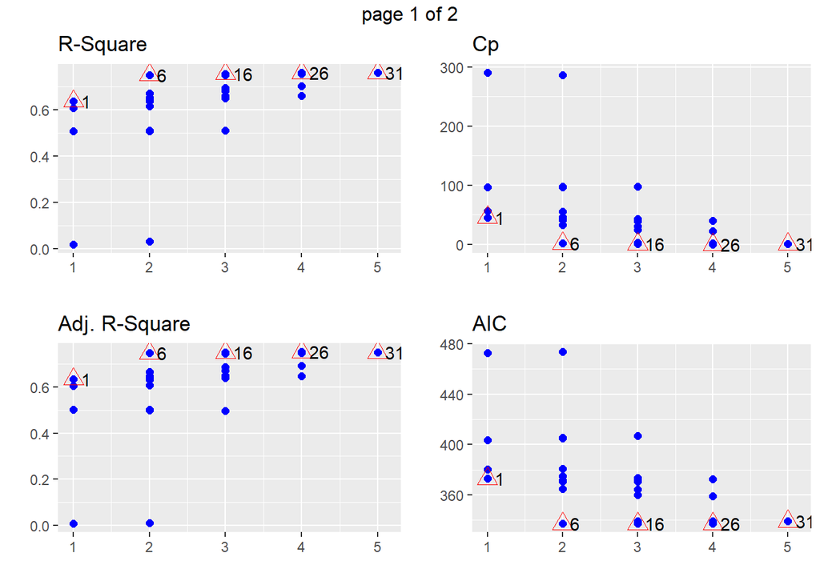

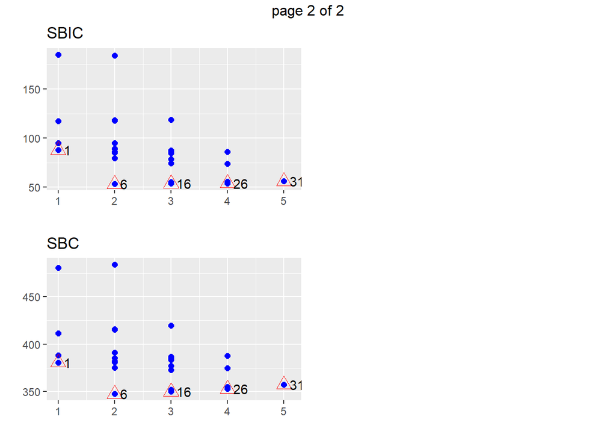

```r
plot(k)# el eje horizontal representa la cantidad de variables utilizadas en cada modelo.
```

Se ve que el sexto sería uno de los mejores modelos.

Selecciona el subconjunto de predictores que alcanzan mayor R2 o menor MSE, Mallow’s Cp o AIC, etc.

```r
k_best <- ols_step_best_subset(lm.fit1)

# AIC: Akaike Information Criteria
# SBIC: Sawa's Bayesian Information Criteria
# SBC: Schwarz Bayesian Criteria
# MSEP: Estimated error of prediction, assuming multivariate normality
# FPE: Final Prediction Error
# HSP: Hocking's Sp
# APC: Amemiya Prediction Criteria

k_best
```

|  | mindex | n | predictors | rsquare | adjr | predrsq | cp | aic | sbic | sbc | msep | fpe | apc | hsp |
| --- | --- | --- | --- | --- | --- | --- | --- | --- | --- | --- | --- | --- | --- | --- |
| 3 | 1 | 1 | birthwt | 0.6381409 | 0.6344485 | 0.6246540 | 46.628891 | 372.9438 | 87.78188 | 380.7593 | 234.3786 | 2.390652 | 0.3766288 | 0.02416264 |
| 10 | 2 | 2 | gestage birthwt | 0.7519920 | 0.7468784 | 0.7322200 | 3.753827 | 337.1644 | 53.51350 | 347.5851 | 162.3098 | 1.671606 | 0.2633487 | 0.01690540 |
| 23 | 3 | 3 | gestage birthwt toxemia | 0.7568754 | 0.7492778 | 0.7256323 | 3.828984 | 337.1757 | 53.73239 | 350.2015 | 160.7887 | 1.671836 | 0.2633850 | 0.01692142 |
| 30 | 4 | 4 | gestage birthwt momage toxemia | 0.7614750 | 0.7514319 | 0.7252208 | 4.016022 | 337.2657 | 54.10636 | 352.8967 | 159.4249 | 1.673410 | 0.2636329 | 0.01695450 |
| 31 | 5 | 5 | length gestage birthwt momage toxemia | 0.7615157 | 0.7488303 | 0.7234962 | 6.000000 | 339.2486 | 56.21874 | 357.4848 | 161.1117 | 1.707028 | 0.2689291 | 0.01731617 |

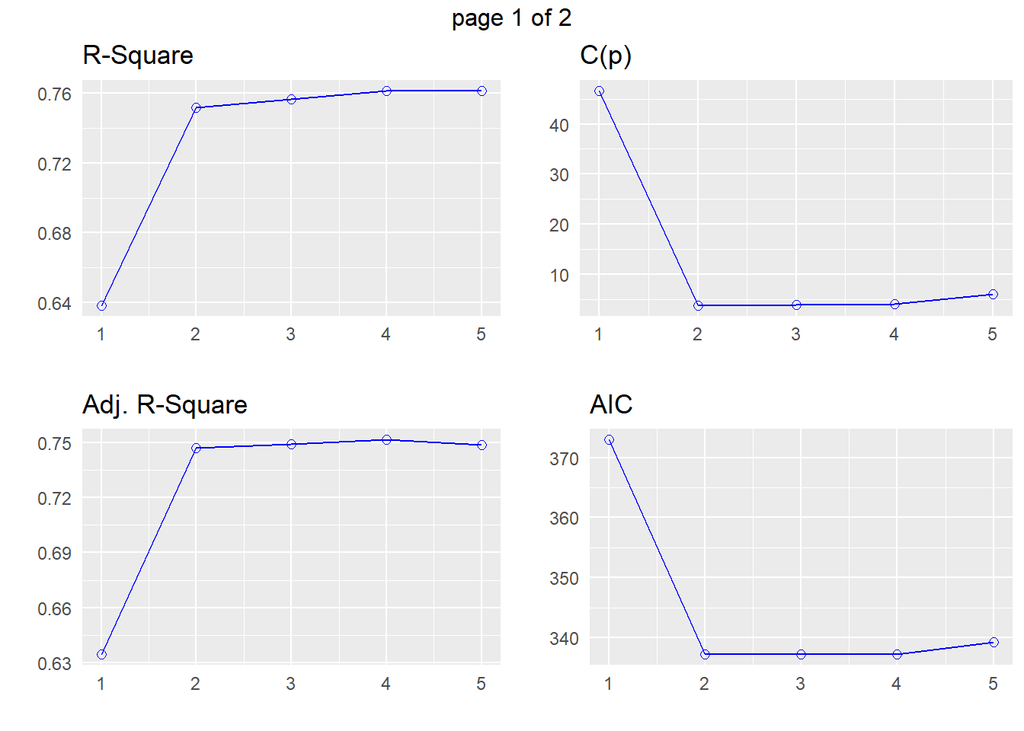

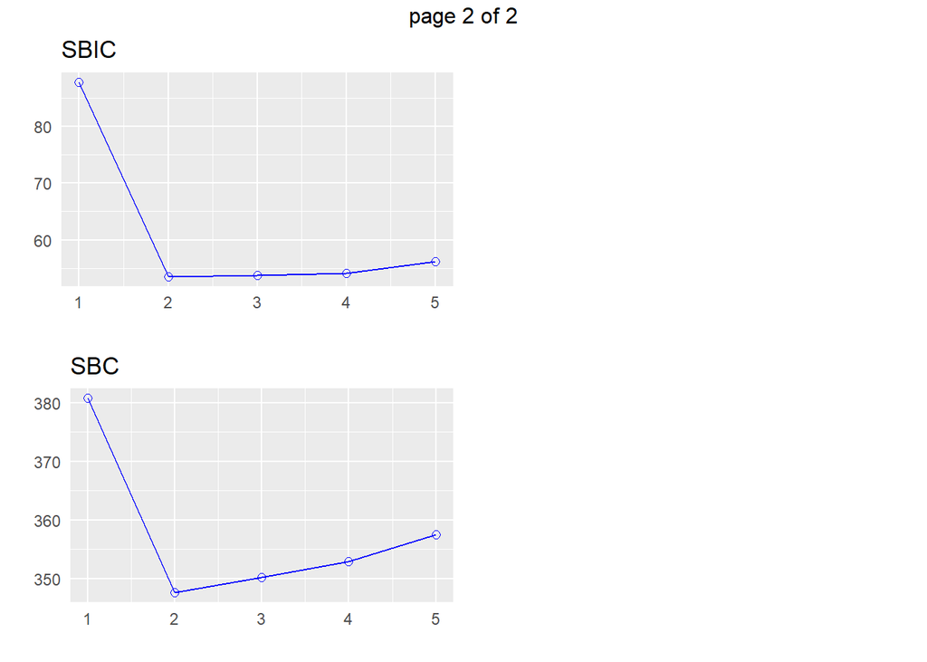

```r
plot(k_best)# el eje horizontal representa la cantidad de variables utilizadas en cada modelo.
```

El mejor se puede ver que es el segundo, coincide con el análisis anterior.

## Validación cruzada

### Validación simple

Para la validación utilizaremos como muestra de entrenamiento el 66% de las observaciones seleccionadas aleatoriamente. El 34% restante se reservará para la muestra de test.

```r
set.seed(1)


train <- sample(x = 1:100, size = 67, replace = FALSE)

mejores_modelos <- regsubsets(headcirc ~ ., data = data[train,], nvmax = 5,method = "forward")

# Se genera un vector que almacenará el test-error de cada modelo
validation_error <- rep(NA, 5)
```

La función model.matrix() devuelve una matriz formada con los predictores indicados en la fórmula e introduce para todas las observaciones un intercept con valor 1, así al multiplicar por los coeficientes se obtiene el valor de la predicción.

```r
test_matrix <- model.matrix(headcirc ~ ., data = data[-train,])
# Para cada uno de los modelos almacenados en la variable mejores modelos:
for (i in 1:5) {
  # Se extraen los coeficientes del modelo
  coeficientes <- coef(object = mejores_modelos, id = i)
  # Se identifican los predictores que forman el modelo y se extraen de la
  # matriz modelo
  predictores <- test_matrix[, names(coeficientes)]
  # Se obtienen las predicciones mediante el producto matricial de los
  # predictores extraídos y los coeficientes del modelo
  predicciones <- predictores %*% coeficientes
  # Finalmente se calcula la estimación del test error como el promedio de los
  # residuos al cuadrado (MSE)
  validation_error[i] <- mean((data$headcirc[-train] - predicciones)^2) }
which.min(validation_error)
```

```
## [1] 4
```

Graficamos los errores en función del número de covariables (predictores).

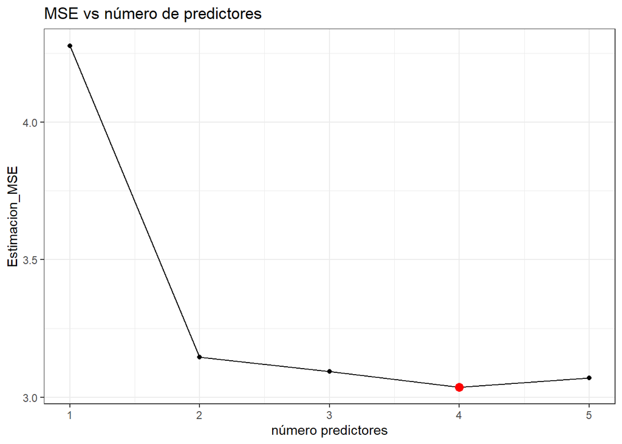

```r
p <- ggplot(data = data.frame(n_predictores = 1:5, Estimacion_MSE = validation_error), aes(x = n_predictores, y = Estimacion_MSE)) +
  geom_line() +
  geom_point()
# Se identifica en rojo el mínimo
p <- p + geom_point(aes(x = n_predictores[which.min(validation_error)], y = validation_error[which.min(validation_error)]), colour = "red", size = 3)
p <- p + scale_x_continuous(breaks = c(0:5)) +
  labs(title = "MSE vs número de predictores", x = "número predictores") +
  theme_bw()
p
```

Marca en rojo el 4, que es el de mínimo error estimado.

### Validación cruzada (CV)

La validación simple tiene la desventaja de sufrir mucha varianza, es decir, las estimaciones del error pueden variar mucho según cómo sean las muestras de entrenamiento y test. Es por eso que se utiliza el método de validación cruzada (K-Cross-Validation), el cual consiste en dividir el conjunto de observaciones en k grupos de tamaño similar.

A continuación se muestra un ejemplo considerando k=10.

```r
set.seed(11)
# Sample() mezcla aleatoriamente las posiciones.
# Es importante que la asignación sea aleatoria.
grupo <- sample(rep(x = 1:10, length = nrow(data)))
# Se comprueba que la distribución es aproximadamente equitativa
table(grupo)
```

```
## grupo
##  1  2  3  4  5  6  7  8  9 10
## 10 10 10 10 10 10 10 10 10 10
```

```r
predict.regsubsets <- function(object, newdata, id, ...) {
  # Extraer la fórmula del modelo (variable dependiente ~ predictores)
  form <- as.formula(object$call[[2]])
  # Generar una matriz modelo con los nuevos datos y la fórmula
  mat <- model.matrix(form, newdata)
  # Extraer los coeficientes del modelo
  coefi <- coef(object, id = id)
  # Almacenar el nombre de las variables predictoras del modelo
  xvars <- names(coefi)
  # Producto matricial entre los coeficientes del modelo y los valores de los
  # predictores de las nuevas observaciones para obtener las predicciones
  mat[, xvars] %*% coefi }

error_matrix <- matrix(data = NA, nrow = 10, ncol = 5, dimnames = list(NULL, c(1:5)))
# Loop en el que se excluye en cada iteración un grupo distinto
# ESTE LOOP ESTA HECHO PARA UN DATA FRAME CON 5 PREDICTORES
num_validaciones <- 10
num_predictores <- 5
for (k in 1:num_validaciones) {
  # Identificación de datos empleados como training
  train <- data[grupo != k, ]
  # Selección de los mejores modelos para cada tamaño basándose en RSS
  mejores_modelos <- regsubsets(headcirc ~ ., data = train, nvmax = 5, method = "forward")
  # Para cada uno de los modelos 'finalistas' se calcula el test-error con el
  # grupo excluido
  for (i in 1:num_predictores) {
    test <- data[grupo == k, ]
    # Las predicciones del modelo i almacenado en el objeto regsubsets se
    # extraen mediante la función predict.regsubsets() definida arriba
    predicciones <- predict.regsubsets(object = mejores_modelos, newdata = test, id = i)
    # Cálculo y almacenamiento del MSE para el modelo i
    error_matrix[k, i] <- mean((test$headcirc - predicciones)^2) } }
# Cada columna de la matriz error_matrix contiene los 10 valores de error
# calculados por cv
mean_cv_error <- apply(X = error_matrix, MARGIN = 2, FUN = mean)
# plot(sqrt(mean_cv_error), type = 'b', pch = 19)
which.min(x = mean_cv_error)
```

```
## 2
## 2
```

Graficamos los errores.

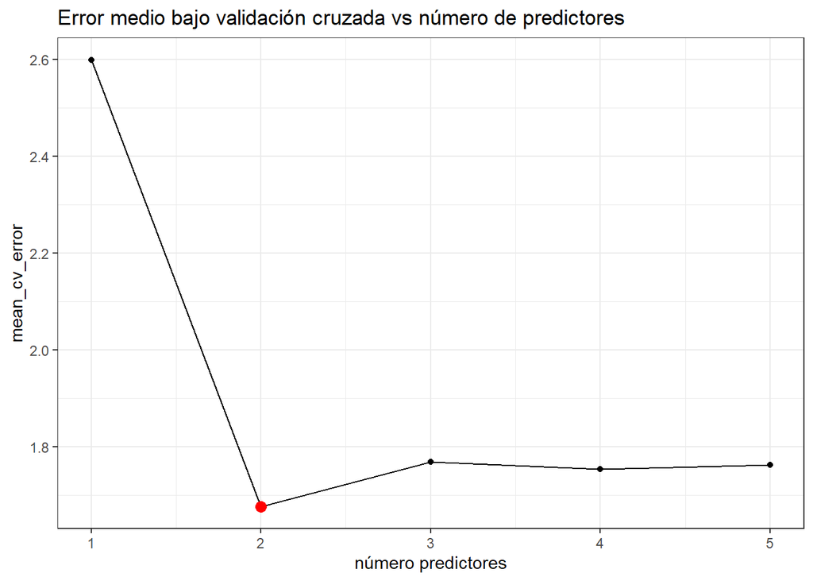

```r
ggplot(data = data.frame(n_predictores = 1:5, mean_cv_error = mean_cv_error), aes(x = n_predictores, y = mean_cv_error)) +
  geom_line() + geom_point() +
  geom_point(aes(x = n_predictores[which.min(mean_cv_error)], y = mean_cv_error[which.min(mean_cv_error)]), colour = "red", size = 3) +
  scale_x_continuous(breaks = c(0:5)) + theme_bw() +
  labs(title = "Error medio bajo validación cruzada vs número de predictores", x = "número predictores")
```

Se identifica el mejor modelo formado por 2 predictores empleando todas las observaciones (training + test).

```r
modelo_final <- regsubsets(headcirc ~ ., data = data, nvmax = 5, method ="forward")
coef(object = modelo_final, 2)
```

```
## (Intercept)     gestage     birthwt
## 8.308015388 0.448732848 0.004712283
```

Notar que siempre lo más conveniente es elegir la mínima cantidad de predictores tales que se observa una disminución significativa del error cuadrático medio (ECM/MSE); y no necesariamente coincide con el k tal que MSE es mínimo como se observa en este caso (Principio de parsimonia).

## Validación simple

```r
library(tidyverse)# paquete de visualización y manipulación  de datos

#install.packages("caret")
library(caret) #paquete para computar directamente CV

set.seed(2022)

# Entrenamos con el 67% de los datos
random_sample <- createDataPartition(data$headcirc,p = 0.67, list = FALSE)
training_dataset <- data[random_sample, ]
testing_dataset <- data[-random_sample, ]

model1 <- lm(headcirc ~., data = training_dataset)

predictions1 <- predict(model1, testing_dataset)

# Métricas de performance
data.frame( R2 = R2(predictions1, testing_dataset $ headcirc),
            RMSE = RMSE(predictions1, testing_dataset $ headcirc),
            MAE = MAE(predictions1, testing_dataset $ headcirc))
```

| R2 | RMSE | MAE |
| --- | --- | --- |
| 0.5208495 | 1.876768 | 0.9701878 |

## Leave one out cross validation (LOOCV)

```r
set.seed(12345)
train_control2 <- trainControl(method = "LOOCV")
model2 <- train(headcirc ~., data = data,method = "lm",trControl = train_control2)
print(model2)
```

```
## Linear Regression
##
## 100 samples
##   5 predictor
##
## No pre-processing
## Resampling: Leave-One-Out Cross-Validation
## Summary of sample sizes: 99, 99, 99, 99, 99, 99, ...
## Resampling results:
##
##   RMSE      Rsquared   MAE
##   1.324805  0.7240097  0.7906253
##
## Tuning parameter 'intercept' was held constant at a value of TRUE
```

## K-fold cross-validation

```r
set.seed(12345)
train_control3 <- trainControl(method = "cv",number = 10)
model3 <- train(headcirc ~., data = data,method = "lm",trControl = train_control3)
print(model3)
```

```
## Linear Regression
##
## 100 samples
##   5 predictor
##
## No pre-processing
## Resampling: Cross-Validated (10 fold)
## Summary of sample sizes: 90, 89, 90, 90, 90, 90, ...
## Resampling results:
##
##   RMSE      Rsquared  MAE
##   1.112772  0.843625  0.8043273
##
## Tuning parameter 'intercept' was held constant at a value of TRUE
```

## Repeated K-fold cross-validation

```r
set.seed(12345)
train_control4 <- trainControl(method = "repeatedcv", number = 10, repeats = 3)
model4 <- train(headcirc ~., data = data, method = "lm",trControl = train_control4)
print(model4)
```

```
## Linear Regression
##
## 100 samples
##   5 predictor
##
## No pre-processing
## Resampling: Cross-Validated (10 fold, repeated 3 times)
## Summary of sample sizes: 90, 89, 90, 90, 90, 90, ...
## Resampling results:
##
##   RMSE      Rsquared   MAE
##   1.158871  0.8021616  0.8049678
##
## Tuning parameter 'intercept' was held constant at a value of TRUE
```